# Principal Components

# Heirarchical Clustering

We will use the same data but this time try heirarchical clustering.

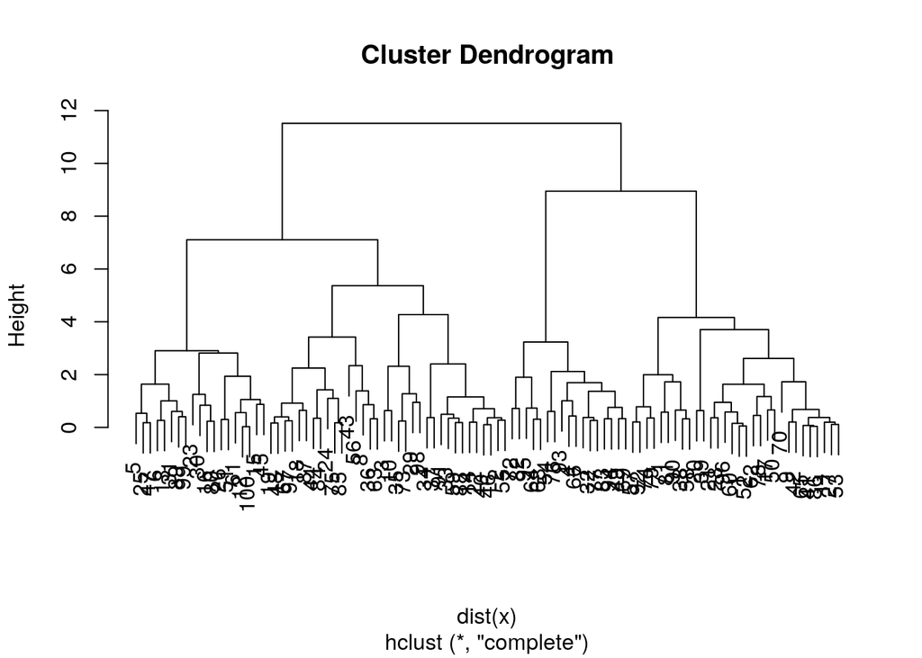

```r
hc.complete=hclust(dist(x),method='complete')
# dist(x) computes the distance of x in a 100x100
# pairwise distance matrix; make a call to `hclust`
# for heirarchical clustering
# here 'complete' method uses farthest point in each
# cluster to determine cluster distance
plot(hc.complete)
```

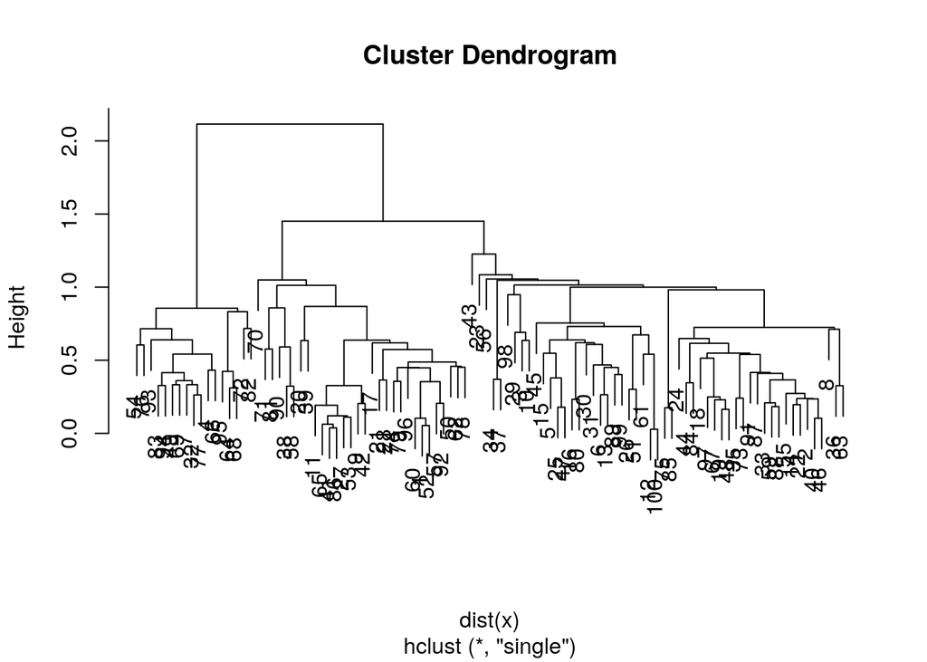

```r
# plots a dendrogram to show the clustering results;
# heights of the arms of the dendrogram clearly
# show 4 quite distinct clusters
hc.single=hclust(dist(x),method='single')
# here 'single' method uses closest point in each
# cluster to determine cluster distance
plot(hc.single)
```

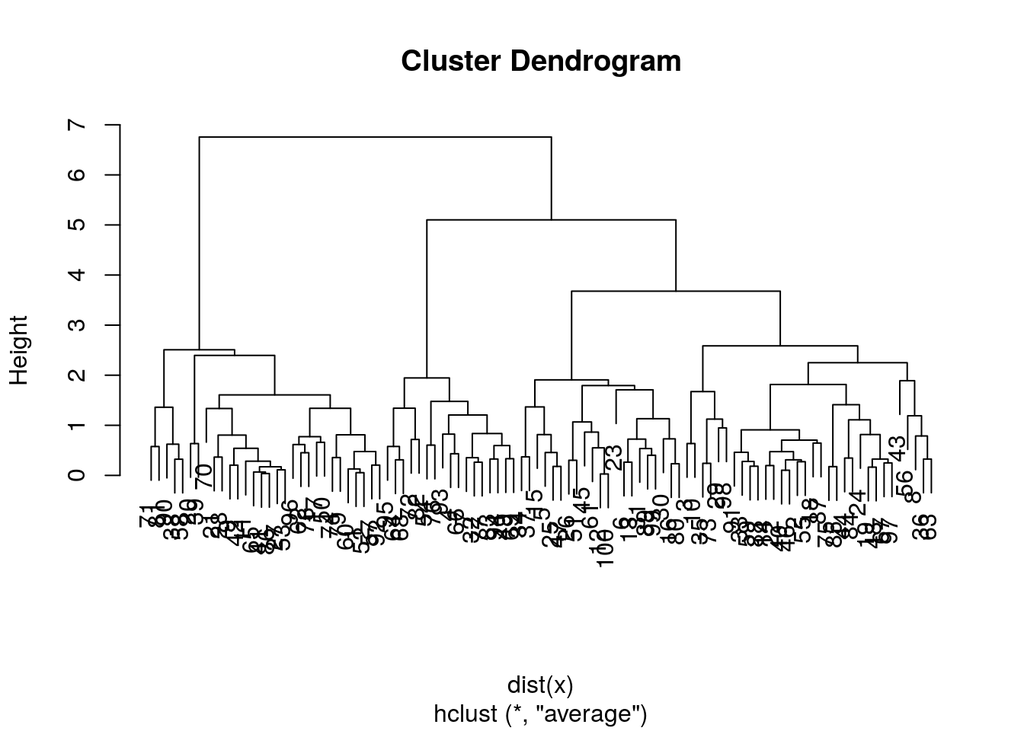

```r
# notice here that the clusters are not as clearly
# defined and 'single' seems to find 3 main clusters;
# 'single' method tends to find long, stringy clusters
# due to the shortest point-point distance measurement
hc.average=hclust(dist(x),method='average')
# here 'average' method uses average of point positions
# in each cluster to determine cluster distance
plot(hc.average)
```

```r
# results are somewhere in between 'complete' and 'single'
```

Let’s compare this with the actual clusters in the data. We will use the function `cutree` to cut the tree at level 4. This will produce a vector of numbers from 1 to 4, saying which branch each observation is on. You will sometimes see pretty plots where the leaves of the dendrogram are colored.

We can use `table` to see how well they match.

```r
hc.cut=cutree(hc.complete,4)
# with `cutree` you give it the hclust results and
# a cutoff point, here we cut at 4 clusters
table(hc.cut,which)
```

```
##       which
## hc.cut  1  2  3  4
##      1  0  0 30  0
##      2  1 31  0  2
##      3 17  0  0  0
##      4  0  0  0 19
```

```r
# creating table from results of `cutree` and the
# true assignments of the data given by which in this
# demonstration (table order is arbitrary);
# in the table there should be 4 large numbers corresponding
# to points contained in the 4 clusters, with zeros
# elsewhere; we see the expected 4 large numbers
# and a few small numbers that tell us there
# are some misclassifications from heirarchical clustering
table(hc.cut,km.out$cluster)
```

```
##
## hc.cut  1  2  3  4
##      1  0 30  0  0
##      2  2  0 32  0
##      3  0  0  0 17
##      4 19  0  0  0
```

```r
# compares the results of heirarchical vs. K-means
# clustering showing disagreement on two points,
# but mostly consistent
```

or we can use our group membership as labels for the leaves of the dendrogram:

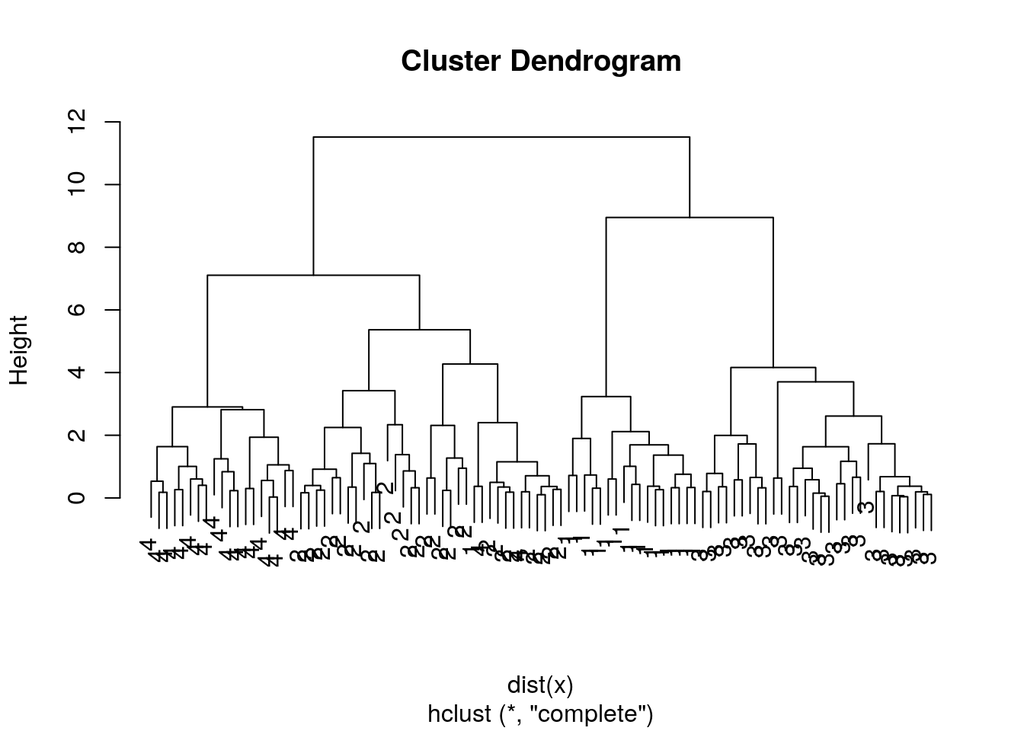

```r
plot(hc.complete,labels=which)
```

```r
# uses the true cluster assignments from which
# and compares to the leaves of the dendrogram
# from heirarchical clustering method
```